# DAY 3 - GENERALIZED LINEAR REGRESSION

Tamas Nagy

2022-07-14

```r
knitr::opts_chunk$set(echo = TRUE)

suppressPackageStartupMessages(library(tidyverse))
suppressPackageStartupMessages(library(here))
suppressPackageStartupMessages(library(sjPlot))
library(broom)
library(performance)

theme_set(theme_light())
```

# Predicting the Titanic survivors

We will use the titanic dataset to predict who died and who survived. We use a model that includes sex, the price of the ticket, the number of spouses and sibilings, and the number of parents and children. We also include the interactions of the ticket price and sex.

```r
library(titanic) # This is for the dataset

titanic <-
    titanic_train %>%
    rename_all(str_to_lower) %>%
    as_tibble() %>%
    # We will center the fare variable
    mutate(fare = scale(fare, scale = FALSE) %>% as.numeric())

# Check codebook
# ?titanic_train

# Fit logistic binomial regression
titanic_fit <- glm(survived ~ fare  * sex + sibsp + parch,
                   family = "binomial",
                   data = titanic)

summary(titanic_fit)
```

```
##
## Call:
## glm(formula = survived ~ fare * sex + sibsp + parch, family = "binomial",
##     data = titanic)
##
## Deviance Residuals:
##     Min       1Q   Median       3Q      Max
## -2.8426  -0.6403  -0.6065   0.7931   2.5313
##
## Coefficients:
##               Estimate Std. Error z value Pr(>|z|)
## (Intercept)   1.522477   0.189353   8.040 8.95e-16 ***
## fare          0.027452   0.007071   3.882 0.000103 ***
## sexmale      -2.755865   0.203544 -13.539  < 2e-16 ***
## sibsp        -0.381103   0.099326  -3.837 0.000125 ***
## parch        -0.197622   0.114195  -1.731 0.083529 .
## fare:sexmale -0.016071   0.007454  -2.156 0.031093 *
## ---
## Signif. codes:  0 '***' 0.001 '**' 0.01 '*' 0.05 '.' 0.1 ' ' 1
##
## (Dispersion parameter for binomial family taken to be 1)
##
##     Null deviance: 1186.66  on 890  degrees of freedom
## Residual deviance:  853.22  on 885  degrees of freedom
## AIC: 865.22
##
## Number of Fisher Scoring iterations: 6
```

```r
tidy(titanic_fit)
```

```
## # A tibble: 6 × 5
##   term         estimate std.error statistic  p.value
##   <chr>           <dbl>     <dbl>     <dbl>    <dbl>
## 1 (Intercept)    1.52     0.189        8.04 8.95e-16
## 2 fare           0.0275   0.00707      3.88 1.03e- 4
## 3 sexmale       -2.76     0.204      -13.5  9.15e-42
## 4 sibsp         -0.381    0.0993      -3.84 1.25e- 4
## 5 parch         -0.198    0.114       -1.73 8.35e- 2
## 6 fare:sexmale  -0.0161   0.00745     -2.16 3.11e- 2
```

```r
glance(titanic_fit)
```

```
## # A tibble: 1 × 8
##   null.deviance df.null logLik   AIC   BIC deviance df.residual  nobs
##           <dbl>   <int>  <dbl> <dbl> <dbl>    <dbl>       <int> <int>
## 1         1187.     890  -427.  865.  894.     853.         885   891
```

To get the odds ratio, use the `exp()` function on the coefficients.

We can also calculate confidence intervals for the ORs.

```r
exp(confint(titanic_fit))
```

```
##                   2.5 %     97.5 %
## (Intercept)  3.21873438 6.79784410
## fare         1.01540837 1.04406486
## sexmale      0.04192598 0.09345825
## sibsp        0.55666745 0.82367967
## parch        0.65541332 1.02858693
## fare:sexmale 0.96833443 0.99725307
```

But instead, we can use the `tidy()` function to exponentiate coefficients and provide confidence intervals.

```r
tidy(titanic_fit, conf.int = TRUE, exponentiate = TRUE)
```

```
## # A tibble: 6 × 7
##   term         estimate std.error statistic  p.value conf.low conf.high
##   <chr>           <dbl>     <dbl>     <dbl>    <dbl>    <dbl>     <dbl>
## 1 (Intercept)    4.58     0.189        8.04 8.95e-16   3.22      6.80
## 2 fare           1.03     0.00707      3.88 1.03e- 4   1.02      1.04
## 3 sexmale        0.0636   0.204      -13.5  9.15e-42   0.0419    0.0935
## 4 sibsp          0.683    0.0993      -3.84 1.25e- 4   0.557     0.824
## 5 parch          0.821    0.114       -1.73 8.35e- 2   0.655     1.03
## 6 fare:sexmale   0.984    0.00745     -2.16 3.11e- 2   0.968     0.997
```

Let’s plot the data. Please mind that you need to tweek the arguments for `geom_smooth()` to fit a binomial logistic function.

# Plotting logistic regression

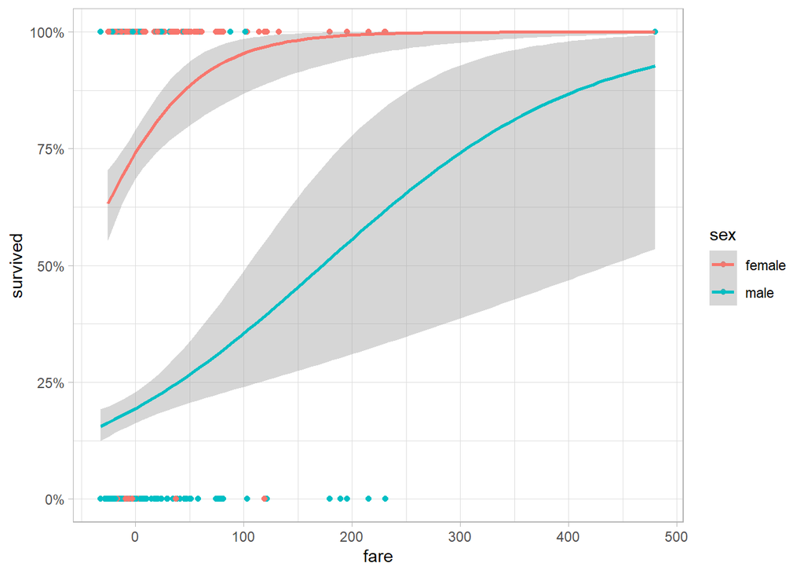

```r
# In this plot, we will only include sex and ticket price as predictors.
ggplot(titanic) +
    aes(y = survived, x = fare, group = sex, color = sex) +
    geom_point() +
    geom_smooth(method = "glm",
                method.args = list(family = "binomial")) +
    coord_cartesian(ylim = c(0, 1)) +
    scale_y_continuous(labels = scales::percent_format())
```

## Evaluating a logistic regression model

R2 cannot be calculated for glm as for linear regression, and also might not be the most useful metric. However, it is possible to calculate pseudo R2. The `{performance}` package offers several calculation methods, and also chooses the best one for the model. For a more detailed discussion on pseudo R2s, see: https://stats.oarc.ucla.edu/other/mult-pkg/faq/general/faq-what-are-pseudo-r-squareds/.

```r
r2(titanic_fit)
```

```
## # R2 for Logistic Regression
##   Tjur's R2: 0.348
```

## Model predictions

To get the predictions of the model, we can use the `augment()` function from the `{broom}` package. The prediction of the GLM can either be on the scale of the predictors (“link”), or in the scale of the outcome (“response”). Thus for a binomial model the default predictions are of log-odds (probabilities on logit scale) and type = “response” gives the predicted probabilities.

```r
augment(titanic_fit, type.predict = "response")
```

```
## # A tibble: 891 × 11
##    survived   fare sex    sibsp parch .fitted .resid .std.resid    .hat .sigma
##       <int>  <dbl> <chr>  <int> <int>   <dbl>  <dbl>      <dbl>   <dbl>  <dbl>
##  1        0 -25.0  male       1     0  0.130  -0.528     -0.529 0.00249  0.982
##  2        1  39.1  female     1     0  0.902   0.455      0.458 0.0130   0.982
##  3        1 -24.3  female     0     0  0.702   0.842      0.845 0.00710  0.982
##  4        1  20.9  female     1     0  0.847   0.575      0.578 0.00953  0.982
##  5        0 -24.2  male       0     0  0.181  -0.632     -0.633 0.00221  0.982
##  6        0 -23.7  male       0     0  0.182  -0.634     -0.634 0.00220  0.982
##  7        0  19.7  male       0     0  0.267  -0.788     -0.790 0.00373  0.982
##  8        0 -11.1  male       3     1  0.0629 -0.361     -0.361 0.00496  0.982
##  9        1 -21.1  female     0     2  0.634   0.955      0.962 0.0137   0.982
## 10        1  -2.13 female     1     0  0.747   0.764      0.766 0.00564  0.982
## # … with 881 more rows, and 1 more variable: .cooksd <dbl>
```

Calculating and plotting the ROC curve, and calculating the ROC AUC are easy with the `{performance}` package.

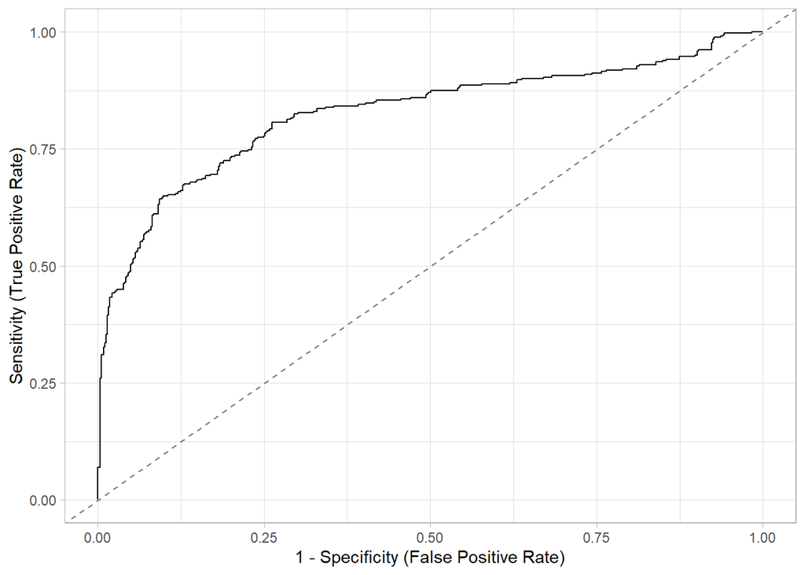

```r
surv_roc <- performance_roc(titanic_fit)

# ROC curve
plot(surv_roc)
```

```r
# ROC AUC
surv_roc
```

```
## AUC: 82.58%
```

## Reporting logistic regression paramters

```r
tab_model(titanic_fit,
          show.aic = TRUE,
          show.loglik = TRUE,
          collapse.se = TRUE
)
```

|  | survived |  |  |
| --- | --- | --- | --- |
| Predictors | Odds Ratios | CI | p |
| (Intercept) | 4.58 (0.87) | 3.22 – 6.80 | **<0.001** |
| fare | 1.03 (0.01) | 1.02 – 1.04 | **<0.001** |
| sex [male] | 0.06 (0.01) | 0.04 – 0.09 | **<0.001** |
| sibsp | 0.68 (0.07) | 0.56 – 0.82 | **<0.001** |
| parch | 0.82 (0.09) | 0.66 – 1.03 | 0.084 |
| fare * sex [male] | 0.98 (0.01) | 0.97 – 1.00 | **0.031** |
| Observations | 891 |  |  |
| R<sup>2</sup> Tjur | 0.348 |  |  |
| AIC | 865.222 |  |  |
| log-Likelihood | -426.611 |  |  |

# Multinomial logistic regression

In multinomial regression, we are performing classification for an outcome that can take more than two nominal values that cannot be ordered. We are going to classify penguins from the `{palmerpenguins}` dataset into three possible categories. Data source: https://allisonhorst.github.io/palmerpenguins/

```r
library(palmerpenguins)
library(nnet)# Contains the multinom function

penguins
```

```
## # A tibble: 344 × 8
##    species island    bill_length_mm bill_depth_mm flipper_length_mm body_mass_g
##    <fct>   <fct>              <dbl>         <dbl>             <int>       <int>
##  1 Adelie  Torgersen           39.1          18.7               181        3750
##  2 Adelie  Torgersen           39.5          17.4               186        3800
##  3 Adelie  Torgersen           40.3          18                 195        3250
##  4 Adelie  Torgersen           NA            NA                  NA          NA
##  5 Adelie  Torgersen           36.7          19.3               193        3450
##  6 Adelie  Torgersen           39.3          20.6               190        3650
##  7 Adelie  Torgersen           38.9          17.8               181        3625
##  8 Adelie  Torgersen           39.2          19.6               195        4675
##  9 Adelie  Torgersen           34.1          18.1               193        3475
## 10 Adelie  Torgersen           42            20.2               190        4250
## # … with 334 more rows, and 2 more variables: sex <fct>, year <int>
```

```r
# The number of obervations for each species
penguins %>%
  count(species)
```

```
## # A tibble: 3 × 2
##   species       n
##   <fct>     <int>
## 1 Adelie      152
## 2 Chinstrap    68
## 3 Gentoo      124
```

```r
penguin_mn <- multinom(species ~ bill_length_mm +
                       flipper_length_mm,
                       data = penguins)
summary(penguin_mn)
```

```
## Call:
## multinom(formula = species ~ bill_length_mm + flipper_length_mm,
##     data = penguins)
##
## Coefficients:
##           (Intercept) bill_length_mm flipper_length_mm
## Chinstrap   -26.53864      1.3472574        -0.1699613
## Gentoo     -119.39842      0.4815335         0.4805051
##
## Std. Errors:
##           (Intercept) bill_length_mm flipper_length_mm
## Chinstrap    9.903165      0.2303776        0.06476964
## Gentoo       1.597489      0.2115670        0.04956222
##
## Residual Deviance: 78.12858
## AIC: 90.12858
```

The `summary()` function for a `multinom` object is not that informative, e.g. we don’t get tests statistics and p values. We can get those using the `tidy()` function, or `tab_model()`.  
What is immediately obvious is that we get more than one sets of coefficients and std.errors. This is because coefficients are calculated for each outcome with respect to the baseline category.  
A one-unit increase in the predictor variable is associated with the increase in the log odds of classifying a penguin into one category compared to the baseline category.  
Instead of using the default coefficients, it is easier to interpret them as odds ratios after we exponentiate them.

```r
tidy(penguin_mn, exponentiate = TRUE, conf.int = TRUE)
```

```
## # A tibble: 6 × 8
##   y.level   term        estimate std.error statistic  p.value conf.low conf.high
##   <chr>     <chr>          <dbl>     <dbl>     <dbl>    <dbl>    <dbl>     <dbl>
## 1 Chinstrap (Intercept) 2.98e-12    9.90       -2.68 7.37e- 3 1.11e-20  8.02e- 4
## 2 Chinstrap bill_lengt… 3.85e+ 0    0.230       5.85 4.97e- 9 2.45e+ 0  6.04e+ 0
## 3 Chinstrap flipper_le… 8.44e- 1    0.0648     -2.62 8.69e- 3 7.43e- 1  9.58e- 1
## 4 Gentoo    (Intercept) 1.40e-52    1.60      -74.7  0        6.11e-54  3.20e-51
## 5 Gentoo    bill_lengt… 1.62e+ 0    0.212       2.28 2.28e- 2 1.07e+ 0  2.45e+ 0
## 6 Gentoo    flipper_le… 1.62e+ 0    0.0496      9.69 3.17e-22 1.47e+ 0  1.78e+ 0
```

```r
tab_model(penguin_mn)
```

|  | species |  |  |  |
| --- | --- | --- | --- | --- |
| Predictors | Odds Ratios | CI | p | Response |
| (Intercept) | 0.00 | 0.00 – 0.00 | **0.008** | Chinstrap |
| bill length mm | 3.85 | 2.45 – 6.05 | **<0.001** | Chinstrap |
| flipper length mm | 0.84 | 0.74 – 0.96 | **0.009** | Chinstrap |
| (Intercept) | 0.00 | 0.00 – 0.00 | **<0.001** | Gentoo |
| bill length mm | 1.62 | 1.07 – 2.45 | **0.023** | Gentoo |
| flipper length mm | 1.62 | 1.47 – 1.78 | **<0.001** | Gentoo |
| Observations | 342 |  |  |  |
| R<sup>2</sup> / R<sup>2</sup> adjusted | 0.892 / 0.889 |  |  |  |

The model performance can be measured in multiple ways. We can calculate pseudo R2, look at the confusion matrix.

```r
library(yardstick) # for model performance functions
r2(penguin_mn)
```

```
## # R2 for Generalized Linear Regression
##   McFadden's R2: 0.892
```

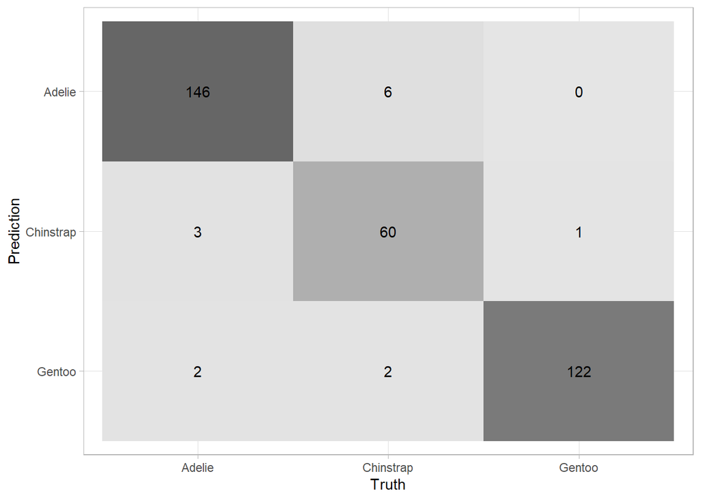

```r
penguins %>%
  mutate(pred = predict(penguin_mn, newdata = .)) %>%
  conf_mat(truth = species, estimate = pred) %>%
  autoplot(type = "heatmap")
```

We can also calculate and visualize the ROC curve, and ROC AUC. This is a bit more complicated for multiclass ROC, as we need to calculate a ROC for pairwise classifications.

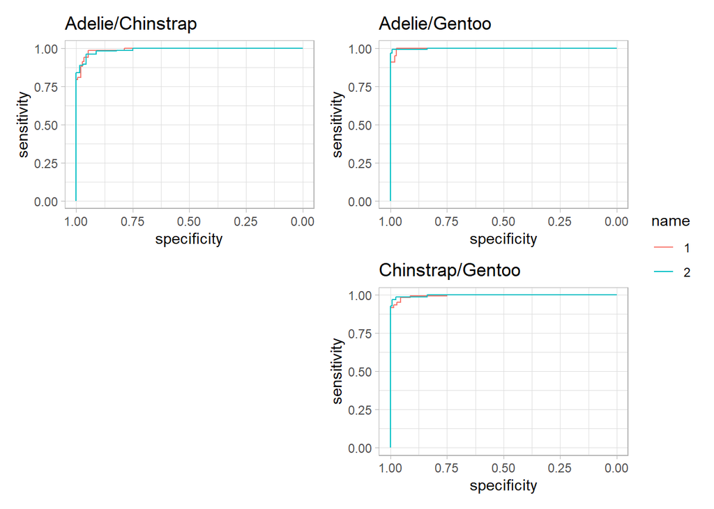

```r
library(pROC) # Can calculate multiclass ROC, but plotting requires cutomization
library(patchwork) # Tool for putting togeter multiple plots

# ROC curve
# Create predictions (probabilities)
penguin_prob <-
  penguins %>%
  mutate(pred = predict(penguin_mn, newdata = ., type = "prob"))

# Calculate the ROC tables
penguin_roc <-
  multiclass.roc(penguin_prob$species, penguin_prob$pred)

# Create ROC plots
roc_plots <-
  map2(penguin_roc[['rocs']], names(penguin_roc[['rocs']]),
       ~ggroc(.x) +
        ggtitle(.y))

# Put all plots into a single plot
roc_plots[[1]] + roc_plots[[2]] + plot_spacer() + roc_plots[[3]] +
plot_layout(ncol = 2, guides = "collect")
```

```r
# Multiclass ROC AUC
penguin_roc
```

```
##
## Call:
## multiclass.roc.default(response = penguin_prob$species, predictor = penguin_prob$pred)
##
## Data: multivariate predictor penguin_prob$pred with 3 levels of penguin_prob$species: Adelie, Chinstrap, Gentoo.
## Multi-class area under the curve: 0.995
```

# Count regression (Poisson)

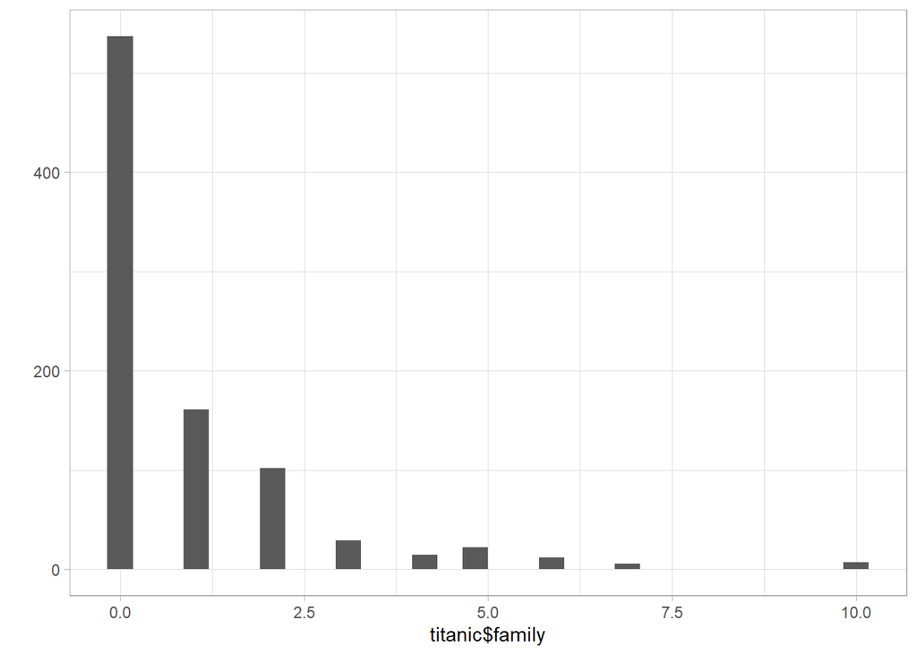

```r
titanic <-
    titanic %>%
    mutate(family = sibsp + parch)

# Check the distribution of family variable
qplot(titanic$family)
```

Yep, definitely Poisson distribution Fitting a Poisson regression is not difficult, just use the `family = "poisson"` parameter.

```r
family_fit_pois <-
  glm(family ~ age, family = "poisson", data = titanic)
```

Check the results. They look very much like the output of logistic regression, only the model summary statistics are different

```r
summary(family_fit_pois)
```

```
##
## Call:
## glm(formula = family ~ age, family = "poisson", data = titanic)
##
## Deviance Residuals:
##     Min       1Q   Median       3Q      Max
## -2.0098  -1.3290  -0.9193   0.5012   4.8543
##
## Coefficients:
##              Estimate Std. Error z value Pr(>|z|)
## (Intercept)  0.882719   0.076914   11.48   <2e-16 ***
## age         -0.035964   0.002918  -12.32   <2e-16 ***
## ---
## Signif. codes:  0 '***' 0.001 '**' 0.01 '*' 0.05 '.' 0.1 ' ' 1
##
## (Dispersion parameter for poisson family taken to be 1)
##
##     Null deviance: 1411.1  on 713  degrees of freedom
## Residual deviance: 1249.5  on 712  degrees of freedom
##   (177 observations deleted due to missingness)
## AIC: 2034.6
##
## Number of Fisher Scoring iterations: 6
```

```r
tidy(family_fit_pois, exponentiate = TRUE, conf.int = TRUE)
```

```
## # A tibble: 2 × 7
##   term        estimate std.error statistic  p.value conf.low conf.high
##   <chr>          <dbl>     <dbl>     <dbl>    <dbl>    <dbl>     <dbl>
## 1 (Intercept)    2.42    0.0769       11.5 1.73e-30    2.08      2.81
## 2 age            0.965   0.00292     -12.3 6.65e-35    0.959     0.970
```

```r
glance(family_fit_pois)
```

```
## # A tibble: 1 × 8
##   null.deviance df.null logLik   AIC   BIC deviance df.residual  nobs
##           <dbl>   <int>  <dbl> <dbl> <dbl>    <dbl>       <int> <int>
## 1         1411.     713 -1015. 2035. 2044.    1250.         712   714
```

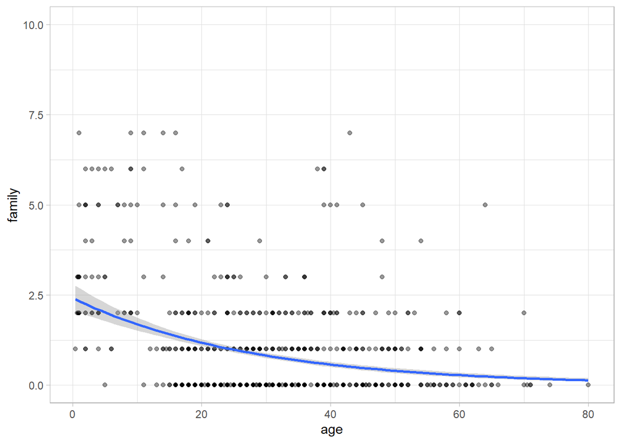

```r
titanic %>%
  ggplot() +
  aes(y = family, x = age) +
  geom_point(alpha = .4) +
  geom_smooth(method = "glm",
              method.args = list(family = "poisson"))
```

However the Poisson regression is not appropriate for data that has a large dispersion. Dispersion should not be significantly larger than 1. We can test the dispersion and zero-inflation like this:

```r
check_overdispersion(family_fit_pois)
```

```
## # Overdispersion test
##
##        dispersion ratio =    2.185
##   Pearson's Chi-Squared = 1555.760
##                 p-value =  < 0.001
```

```
## Overdispersion detected.
```

```r
check_zeroinflation(family_fit_pois)
```

```
## # Check for zero-inflation
##
##    Observed zeros: 404
##   Predicted zeros: 306
##             Ratio: 0.76
```

```
## Model is underfitting zeros (probable zero-inflation).
```

# Negative binomial regression

We have to run a negative binomial regression, since dispersion is 2.2 (variance is more than 2x the mean). The model also shows zero-inflation. However, we will only discuss that later.

```r
# We won't load the MASS package, as it overwrites some functions
family_fit_nb <- MASS::glm.nb(family ~ age, data = titanic)

summary(family_fit_nb)
```

```
##
## Call:
## MASS::glm.nb(formula = family ~ age, data = titanic, init.theta = 0.8294221214,
##     link = log)
##
## Deviance Residuals:
##     Min       1Q   Median       3Q      Max
## -1.3655  -1.1025  -0.8702   0.3423   2.9170
##
## Coefficients:
##              Estimate Std. Error z value Pr(>|z|)
## (Intercept)  0.686135   0.127072   5.400 6.68e-08 ***
## age         -0.028409   0.004214  -6.742 1.56e-11 ***
## ---
## Signif. codes:  0 '***' 0.001 '**' 0.01 '*' 0.05 '.' 0.1 ' ' 1
##
## (Dispersion parameter for Negative Binomial(0.8294) family taken to be 1)
##
##     Null deviance: 727.30  on 713  degrees of freedom
## Residual deviance: 666.85  on 712  degrees of freedom
##   (177 observations deleted due to missingness)
## AIC: 1859.7
##
## Number of Fisher Scoring iterations: 1
##
##
##               Theta:  0.829
##           Std. Err.:  0.112
##
##  2 x log-likelihood:  -1853.734
```

```r
tidy(family_fit_nb, exponentiate = TRUE, conf.int = TRUE)
```

```
## # A tibble: 2 × 7
##   term        estimate std.error statistic  p.value conf.low conf.high
##   <chr>          <dbl>     <dbl>     <dbl>    <dbl>    <dbl>     <dbl>
## 1 (Intercept)    1.99    0.127        5.40 6.68e- 8    1.59      2.49
## 2 age            0.972   0.00421     -6.74 1.56e-11    0.965     0.979
```

```r
glance(family_fit_nb)
```

```
## # A tibble: 1 × 8
##   null.deviance df.null logLik     AIC   BIC deviance df.residual  nobs
##           <dbl>   <int> <logLik> <dbl> <dbl>    <dbl>       <int> <int>
## 1          727.     713 -926.867 1860. 1873.     667.         712   714
```

Let’s plot this. Mind the `geom_smooth()` parameters!

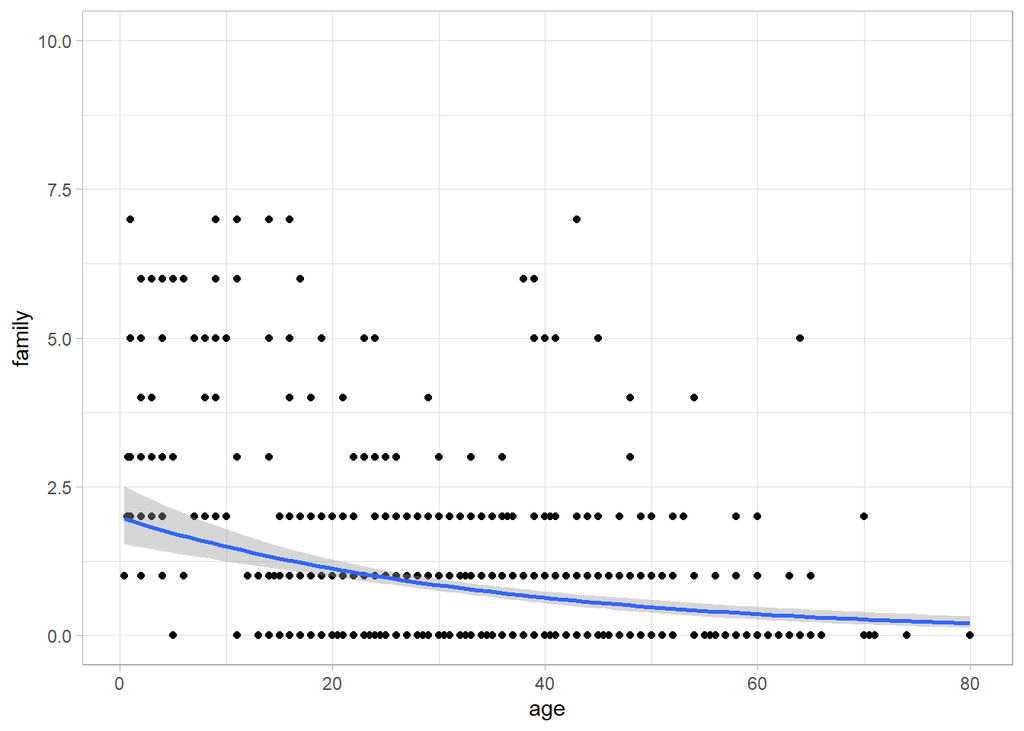

```r
titanic %>%
    ggplot() +
    aes(y = family, x = age) +
    geom_point() +
    geom_smooth(method = MASS::glm.nb)
```

When reporting Poisson/negative binomial regression, you have to report the same things as in logistic regression.

```r
tab_model(family_fit_nb,
          show.aic = TRUE)
```

|  | family |  |  |
| --- | --- | --- | --- |
| Predictors | Incidence Rate Ratios | CI | p |
| (Intercept) | 1.99 | 1.59 – 2.49 | **<0.001** |
| age | 0.97 | 0.96 – 0.98 | **<0.001** |
| Observations | 714 |  |  |
| R<sup>2</sup> Nagelkerke | 0.127 |  |  |
| AIC | 1859.734 |  |  |

# Zero-inflated models

As we saw earlier, the data shows zero-inflation that should be addressed. The ZI model effectively fits two regressions: one binomial regression where we model if there were at least one observation. The other is a count model where we are predicting a number that is larger than zero. It is possible to use different predictors for the two models separated by `|` (not mandatory). The model coefficients can be exponentiated and interpreted as Risk Ratios.

```r
library(pscl)
titanic_zinb <- zeroinfl(family ~ age | age + fare,
                        dist = "negbin",
                        data = titanic)

summary(titanic_zinb)
```

```
##
## Call:
## zeroinfl(formula = family ~ age | age + fare, data = titanic, dist = "negbin")
##
## Pearson residuals:
##      Min       1Q   Median       3Q      Max
## -1.20834 -0.44505 -0.23738  0.07619  5.48255
##
## Count model coefficients (negbin with log link):
##              Estimate Std. Error z value Pr(>|z|)
## (Intercept)  1.116209   0.086443  12.913  < 2e-16 ***
## age         -0.025589   0.002963  -8.635  < 2e-16 ***
## Log(theta)   1.518837   0.294131   5.164 2.42e-07 ***
##
## Zero-inflation model coefficients (binomial with logit link):
##              Estimate Std. Error z value Pr(>|z|)
## (Intercept) -10.93297    1.62136  -6.743 1.55e-11 ***
## age           0.07935    0.01984   4.000 6.34e-05 ***
## fare         -0.45565    0.06493  -7.018 2.25e-12 ***
## ---
## Signif. codes:  0 '***' 0.001 '**' 0.01 '*' 0.05 '.' 0.1 ' ' 1
##
## Theta = 4.5669
## Number of iterations in BFGS optimization: 25
## Log-likelihood: -776.9 on 6 Df
```

```r
# The following function does the exponentiation by default
tab_model(titanic_zinb)
```

|  | family |  |  |  |
| --- | --- | --- | --- | --- |
| Predictors | Incidence Rate Ratios | CI | p |  |
| Count Model |  |  |  |  |
| (Intercept) | 3.05 | 2.58 – 3.62 | **<0.001** |  |
| age | 0.97 | 0.97 – 0.98 | **<0.001** |  |
| Zero-Inflated Model |  |  |  |  |
| (Intercept) | 0.00 | 0.00 – 0.00 | **<0.001** |  |
| age | 1.08 | 1.04 – 1.13 | **<0.001** |  |
| fare | 0.63 | 0.56 – 0.72 | **<0.001** |  |
| Observations | 714 |  |  |  |
| R<sup>2</sup> / R<sup>2</sup> adjusted | 0.421 / 0.420 |  |  |  |

Notice the Log(theta) predictor in the model summary. This is a feature of negative binomial regression, and it means the dispersion term in the model. Read more about it here: https://stats.stackexchange.com/questions/10419/what-is-theta-in-a-negative-binomial-regression-fitted-with-r.

# Cumulative Link Model for Ordinal data

We will use a dataset about the ratings of NYC restaurants from A to C

```r
restaurants_raw <- read_csv(here("data/nyc_restaurants.csv"))
restaurants_raw
```

```
## # A tibble: 121,509 × 7
##       camis dba                 boro  cuisine_descrip… critical_flag score grade
##       <dbl> <chr>               <chr> <chr>            <chr>         <dbl> <chr>
##  1 50053608 CHINA WOK           Broo… Chinese          Not Critical     13 A
##  2 50075410 LA BIENVENIDA REST… Quee… Mexican          Not Critical      8 A
##  3 50005405 ARIA                Manh… Italian          Critical         32 C
##  4 40388218 WALKER'S RESTAURANT Manh… American         Critical         10 A
##  5 50018118 LA LUPE             Broo… Mexican          Not Critical      5 A
##  6 50065335 WEST BAR & LOUNGE   Quee… Caribbean        Not Critical     11 A
##  7 40566706 LA PERLA MEXICANA   Bronx Mexican          Critical          9 A
##  8 50099690 SUBWAY              Bronx Sandwiches       Not Critical      2 A
##  9 50087951 HELL'S KITCHENETTE  Manh… Sandwiches       Critical         13 A
## 10 50016817 TWO BOOTS           Broo… Pizza            Critical         13 A
## # … with 121,499 more rows
```

In order to run an ordinal regression, we need to establish the order of values in the outcome variable by making it a factor.

```r
library(ordinal)
library(parameters)
restaurants <-
  restaurants_raw %>%
  mutate(grade = as.factor(grade),
         # Setting the baseline for the cousine decription to other
         cuisine_description = fct_relevel(cuisine_description, "Other"),
         boro = fct_relevel(boro, "Manhattan"))

# Building the cumulative link model
clm1 <- clm(grade ~ cuisine_description + boro, data = restaurants)
summary(clm1)
```

```
## formula: grade ~ cuisine_description + boro
## data:    restaurants
##
##  link  threshold nobs   logLik    AIC       niter max.grad cond.H
##  logit flexible  121509 -66319.36 132678.71 6(0)  6.67e-08 3.9e+02
##
## Coefficients:
##                                              Estimate Std. Error z value
## cuisine_descriptionAmerican                 -0.450549   0.024363 -18.493
## cuisine_descriptionBakery Products/Desserts  0.004322   0.044553   0.097
## cuisine_descriptionCaribbean                 0.593854   0.039538  15.020
## cuisine_descriptionChicken                  -0.077002   0.051576  -1.493
## cuisine_descriptionChinese                   0.296300   0.026831  11.043
## cuisine_descriptionCoffee/Tea               -0.867690   0.046527 -18.649
## cuisine_descriptionDonuts                   -2.043770   0.119561 -17.094
## cuisine_descriptionItalian                  -0.223518   0.042249  -5.290
## cuisine_descriptionJapanese                  0.223708   0.039494   5.664
## cuisine_descriptionLatin American            0.427260   0.037114  11.512
## cuisine_descriptionMexican                   0.363090   0.038874   9.340
## cuisine_descriptionPizza                    -0.032044   0.034612  -0.926
## cuisine_descriptionSandwiches               -0.074261   0.052541  -1.413
## cuisine_descriptionSpanish                   0.600937   0.041595  14.447
## boroBronx                                    0.117830   0.027051   4.356
## boroBrooklyn                                -0.060641   0.020717  -2.927
## boroQueens                                  -0.009183   0.020547  -0.447
## boroStaten Island                           -0.351542   0.048129  -7.304
##                                             Pr(>|z|)
## cuisine_descriptionAmerican                  < 2e-16 ***
## cuisine_descriptionBakery Products/Desserts  0.92272
## cuisine_descriptionCaribbean                 < 2e-16 ***
## cuisine_descriptionChicken                   0.13544
## cuisine_descriptionChinese                   < 2e-16 ***
## cuisine_descriptionCoffee/Tea                < 2e-16 ***
## cuisine_descriptionDonuts                    < 2e-16 ***
## cuisine_descriptionItalian                  1.22e-07 ***
## cuisine_descriptionJapanese                 1.48e-08 ***
## cuisine_descriptionLatin American            < 2e-16 ***
## cuisine_descriptionMexican                   < 2e-16 ***
## cuisine_descriptionPizza                     0.35456
## cuisine_descriptionSandwiches                0.15754
## cuisine_descriptionSpanish                   < 2e-16 ***
## boroBronx                                   1.33e-05 ***
## boroBrooklyn                                 0.00342 **
## boroQueens                                   0.65493
## boroStaten Island                           2.79e-13 ***
## ---
## Signif. codes:  0 '***' 0.001 '**' 0.01 '*' 0.05 '.' 0.1 ' ' 1
##
## Threshold coefficients:
##     Estimate Std. Error z value
## A|B  1.53807    0.01747   88.07
## B|C  2.89104    0.02045  141.35
```

```r
tab_model(clm1)
```

|  | grade |  |  |
| --- | --- | --- | --- |
| Predictors | Odds Ratios | CI | p |
| A\|B | 4.66 | 4.50 – 4.82 | **<0.001** |
| B\|C | 18.01 | 17.30 – 18.75 | **<0.001** |
| cuisine description [American] | 0.64 | 0.61 – 0.67 | **<0.001** |
| cuisine description [Bakery Products/Desserts] | 1.00 | 0.92 – 1.10 | 0.923 |
| cuisine description [Caribbean] | 1.81 | 1.68 – 1.96 | **<0.001** |
| cuisine description [Chicken] | 0.93 | 0.84 – 1.02 | 0.135 |
| cuisine description [Chinese] | 1.34 | 1.28 – 1.42 | **<0.001** |
| cuisine description [Coffee/Tea] | 0.42 | 0.38 – 0.46 | **<0.001** |
| cuisine description [Donuts] | 0.13 | 0.10 – 0.16 | **<0.001** |
| cuisine description [Italian] | 0.80 | 0.74 – 0.87 | **<0.001** |
| cuisine description [Japanese] | 1.25 | 1.16 – 1.35 | **<0.001** |
| cuisine description [Latin American] | 1.53 | 1.43 – 1.65 | **<0.001** |
| cuisine description [Mexican] | 1.44 | 1.33 – 1.55 | **<0.001** |
| cuisine description [Pizza] | 0.97 | 0.90 – 1.04 | 0.355 |
| cuisine description [Sandwiches] | 0.93 | 0.84 – 1.03 | 0.158 |
| cuisine description [Spanish] | 1.82 | 1.68 – 1.98 | **<0.001** |
| boro [Bronx] | 1.13 | 1.07 – 1.19 | **<0.001** |
| boro [Brooklyn] | 0.94 | 0.90 – 0.98 | **0.003** |
| boro [Queens] | 0.99 | 0.95 – 1.03 | 0.655 |
| boro [Staten Island] | 0.70 | 0.64 – 0.77 | **<0.001** |
| Observations | 121509 |  |  |
| R<sup>2</sup> Nagelkerke | 0.034 |  |  |

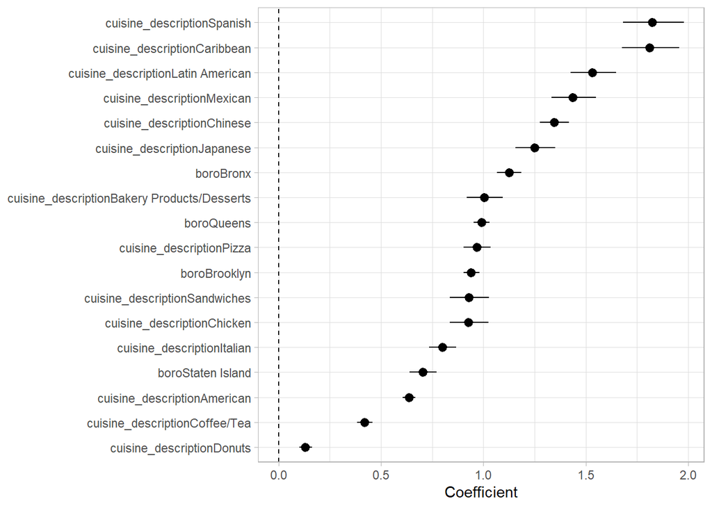

```r
clm_coefs <-
  tidy(clm1, exponentiate = TRUE) %>%
  arrange(-estimate)

model_parameters(clm1, exponentiate = TRUE) %>%
  as_tibble() %>%
  filter(Component == "location") %>%
  mutate(Parameter = fct_reorder(Parameter, Coefficient)) %>%
  ggplot() +
  aes(y = Parameter,
      x = Coefficient,
      xmin = CI_low, xmax = CI_high) +
  geom_vline(xintercept = 0, lty = "dashed") +
  geom_pointrange() +
  ylab(NULL)
```

Testing the model assumption, the proportional odd’s ratio with either the `nominal_test()` or `scale_test()` function.

```r
nominal_test(clm1)
```

```
## Tests of nominal effects
##
## formula: grade ~ cuisine_description + boro
##                     Df logLik    AIC     LRT  Pr(>Chi)
## <none>                 -66319 132679
## cuisine_description 14 -66267 132602 104.550 6.331e-16 ***
## boro                 4 -66302 132651  35.493 3.678e-07 ***
## ---
## Signif. codes:  0 '***' 0.001 '**' 0.01 '*' 0.05 '.' 0.1 ' ' 1
```

```r
scale_test(clm1)
```

```
## Tests of scale effects
##
## formula: grade ~ cuisine_description + boro
##                     Df logLik    AIC     LRT  Pr(>Chi)
## <none>                 -66319 132679
## cuisine_description 14 -66267 132602 104.832 5.586e-16 ***
## boro                 4 -66303 132654  32.427 1.564e-06 ***
## ---
## Signif. codes:  0 '***' 0.001 '**' 0.01 '*' 0.05 '.' 0.1 ' ' 1
```

Let’s plot the data

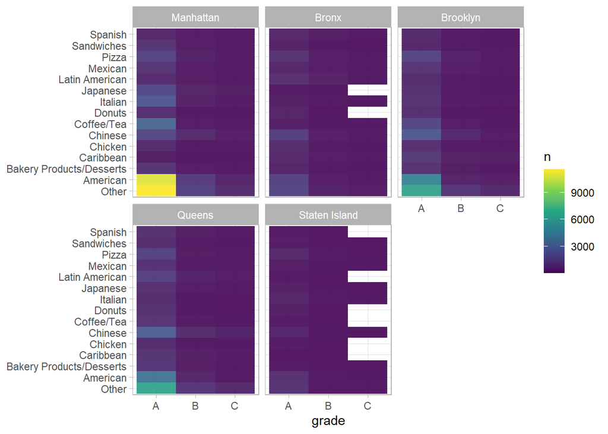

```r
restaurants %>%
  count(cuisine_description, boro, grade) %>%
  ggplot() +
  aes(y = cuisine_description, x = grade, fill = n) +
  geom_tile(alpha = .9) +
  scale_fill_viridis_c() +
  facet_wrap("boro") +
  ylab(NULL)
```